# Factor Analysis #2

Aleksander Molak

January 7, 2020

# Factor Analysis 2

```r
library(psych)
library(sem)
library(dplyr)
```

## Get & transform the the data

```r
# Using Big Five data from `psych` - drop DEMO data
bfi_ <- bfi %>% select(-c(gender, age, education))
```

```r
# Split the data
N <- nrow(bfi_)

indices <- seq(1, N)

indices_EFA <- sample(indices, floor(.5 * N))
indices_CFA <- indices[!(indices %in% indices_EFA)]

bfi_EFA <- bfi_[indices_EFA, ]
bfi_CFA <- bfi_[indices_CFA, ]
```

## Calculate eigenvalues

```r
# Calculate the correlation matrix first
bfi_EFA_cor <- cor(bfi_EFA, use = 'pairwise.complete.obs')

# Then use that correlation matrix to calculate eigenvalues
eigenvals <- eigen(bfi_EFA_cor)

# Look at the eigenvalues returned
eigenvals$values
```

```
##  [1] 5.1092063 2.8602724 2.0351134 1.8699628 1.5002773 1.1164247 0.8567209
##  [8] 0.8013576 0.7446982 0.7244794 0.6924342 0.6336600 0.6243332 0.5766624
## [15] 0.5458999 0.5171792 0.5097410 0.4961232 0.4661749 0.4572588 0.4254350
## [22] 0.4029537 0.3933879 0.3716998 0.2685437
```

## Examine eigenvalues using scree plot

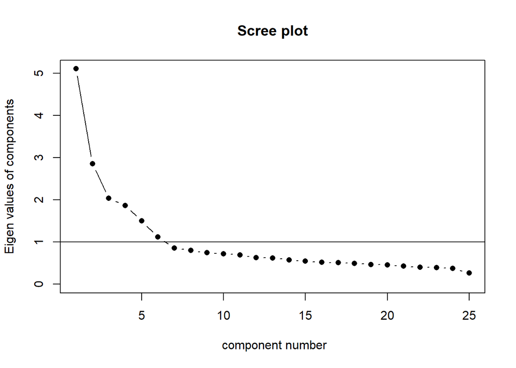

```r
# Calculate the correlation matrix
bfi_EFA_cor <- cor(bfi_EFA, use = "pairwise.complete.obs")

# Then use the correlation matrix to create the a scree plot
# NOTE: `factors = FALSE` because we don't want to perform FA
scree(bfi_EFA_cor, factors = FALSE)
```

```r
# Let's add parrallel analysis
# parallel = fa.parallel(bfi_EFA,
#  # fm = 'ml',
#  fa = 'fa',
#  n.iter = 50,
#  SMC = TRUE,
#  quant = .95)
```

## Build the model

```r
# Scree plot showed 6 factos above 1, let's follow this recommendation
EFA_model <- fa(bfi_EFA, nfactors = 6)
EFA_model
```

```
## Factor Analysis using method =  minres
## Call: fa(r = bfi_EFA, nfactors = 6)
## Standardized loadings (pattern matrix) based upon correlation matrix
##      MR2   MR3   MR1   MR5   MR4   MR6   h2   u2 com
## A1  0.09  0.12 -0.06 -0.57  0.08  0.28 0.34 0.66 1.7
## A2  0.02  0.07  0.00  0.70  0.05 -0.03 0.52 0.48 1.0
## A3  0.00  0.04 -0.13  0.63  0.05  0.08 0.54 0.46 1.1
## A4 -0.05  0.22 -0.03  0.42 -0.12  0.09 0.28 0.72 1.9
## A5 -0.15  0.04 -0.18  0.45  0.10  0.25 0.49 0.51 2.3
## C1  0.01  0.52  0.01 -0.10  0.23  0.09 0.34 0.66 1.5
## C2  0.10  0.66  0.11  0.04  0.11  0.17 0.48 0.52 1.3
## C3  0.00  0.61  0.12  0.08 -0.02  0.08 0.38 0.62 1.2
## C4  0.08 -0.63  0.07 -0.07  0.06  0.30 0.55 0.45 1.5
## C5  0.14 -0.58  0.17  0.01  0.13  0.09 0.47 0.53 1.5
## E1 -0.12  0.11  0.60 -0.12 -0.08  0.08 0.39 0.61 1.3
## E2  0.05 -0.01  0.71 -0.06 -0.03  0.04 0.57 0.43 1.0
## E3 -0.01  0.02 -0.33  0.15  0.38  0.22 0.48 0.52 2.9
## E4 -0.05  0.05 -0.54  0.16  0.04  0.33 0.57 0.43 1.9
## E5  0.16  0.27 -0.37  0.07  0.25  0.03 0.40 0.60 3.1
## N1  0.85  0.01 -0.07 -0.04 -0.06 -0.02 0.69 0.31 1.0
## N2  0.85  0.02 -0.06 -0.04 -0.01 -0.06 0.68 0.32 1.0
## N3  0.66 -0.05  0.11  0.06  0.06  0.08 0.53 0.47 1.1
## N4  0.41 -0.13  0.39  0.06  0.10  0.07 0.46 0.54 2.4
## N5  0.42  0.01  0.23  0.15 -0.06  0.17 0.32 0.68 2.3
## O1 -0.05  0.07 -0.03  0.00  0.57  0.00 0.35 0.65 1.1
## O2  0.11 -0.08  0.02  0.12 -0.33  0.40 0.30 0.70 2.4
## O3 -0.05  0.00 -0.10  0.04  0.63 -0.02 0.45 0.55 1.1
## O4  0.09 -0.04  0.33  0.14  0.42  0.00 0.28 0.72 2.3
## O5  0.02  0.00 -0.02 -0.05 -0.45  0.40 0.36 0.64 2.0
##
##                        MR2  MR3  MR1  MR5  MR4  MR6
## SS loadings           2.48 2.12 2.12 1.96 1.68 0.88
## Proportion Var        0.10 0.08 0.08 0.08 0.07 0.04
## Cumulative Var        0.10 0.18 0.27 0.35 0.41 0.45
## Proportion Explained  0.22 0.19 0.19 0.17 0.15 0.08
## Cumulative Proportion 0.22 0.41 0.60 0.77 0.92 1.00
##
##  With factor correlations of
##       MR2   MR3   MR1   MR5   MR4   MR6
## MR2  1.00 -0.19  0.27 -0.13  0.05  0.18
```

[output cut: 16 more lines]

```
## The total number of observations was  1400  with Likelihood Chi Square =  594.7  with prob <  7.1e-50
##
## Tucker Lewis Index of factoring reliability =  0.922
## RMSEA index =  0.043  and the 90 % confidence intervals are  0.039 0.047
## BIC =  -600.6
## Fit based upon off diagonal values = 0.99
## Measures of factor score adequacy
##                                                    MR2  MR3  MR1  MR5  MR4
## Correlation of (regression) scores with factors   0.93 0.89 0.89 0.88 0.85
## Multiple R square of scores with factors          0.86 0.79 0.79 0.78 0.73
## Minimum correlation of possible factor scores     0.73 0.58 0.59 0.56 0.46
##                                                    MR6
## Correlation of (regression) scores with factors   0.78
## Multiple R square of scores with factors          0.61
## Minimum correlation of possible factor scores     0.21
```

Let’s view factor loadings

```r
EFA_model$loadings
```

```
##
## Loadings:
##    MR2    MR3    MR1    MR5    MR4    MR6
## A1         0.119        -0.573         0.278
## A2                       0.697
## A3               -0.129  0.633
## A4         0.218         0.420 -0.122
## A5 -0.151        -0.179  0.453         0.247
## C1         0.516                0.230
## C2         0.657  0.108         0.109  0.166
## C3         0.607  0.119
## C4        -0.632                       0.297
## C5  0.141 -0.583  0.170         0.134
## E1 -0.120  0.106  0.601 -0.116
## E2                0.707
## E3               -0.335  0.151  0.384  0.220
## E4               -0.539  0.163         0.330
## E5  0.155  0.270 -0.374         0.246
## N1  0.847
## N2  0.846
## N3  0.660         0.112
## N4  0.412 -0.133  0.389         0.104
## N5  0.423         0.226  0.154         0.173
## O1                              0.569
## O2  0.108                0.122 -0.325  0.398
## O3               -0.105         0.634
## O4                0.335  0.135  0.420
## O5                             -0.454  0.402
##
##                  MR2   MR3   MR1   MR5   MR4   MR6
## SS loadings    2.355 1.997 1.864 1.762 1.576 0.824
## Proportion Var 0.094 0.080 0.075 0.070 0.063 0.033
## Cumulative Var 0.094 0.174 0.249 0.319 0.382 0.415
```

## Investigate model fit

### Absolute fit

- can be measured using:
  - Chi-square test
  - Tucker-Lewis Index (TLI)
  - Root Mean Square Error of Approximation (RMSEA)

### Relative fit

- is used to compare two or more models. It can be measured using:
  - BIC
  - AIC

### Assesing model fit - heuristics || Absolute fit

- $\chi^2$ test is dependent on sample size. It’s rare that it’s non-significant when the sample is large. Non-sign. result means a good fit.
- Tucker Lewis Index (**TLI**): > 0.90
- Root Mean Square Error of Approximation (**RMSEA**): < 0.05

### Comparing models fit - heuristics || Relative fit

- The lower the BIC / AIC the better the model fit

Let’s run a comparison between 5 and 6 factor models for `bfi`.

```r
EFA_5 <- fa(bfi_EFA, nfactors = 5)
EFA_6 <- fa(bfi_EFA, nfactors = 6)
```

```r
cat(EFA_5$BIC, EFA_6$BIC)
```

```
## -324.7524 -600.5972
```

It looks like the second model (6 factors has much better fit to the data)!

Let’s visualize it!

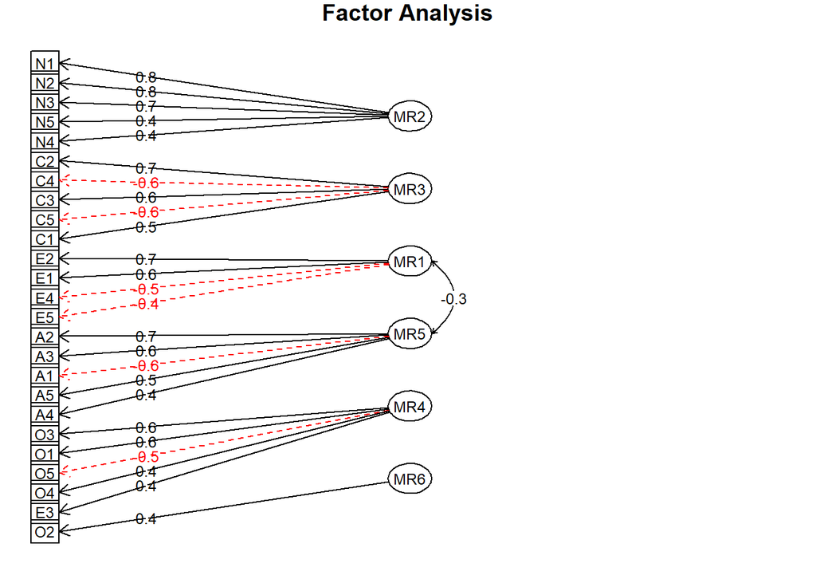

```r
fa.diagram(EFA_6)
```

# CFA - confirmatory factor analysis

To create CFA syntax we can use `structure.sem()` function from `psych` library.

```r
EFA_syntax <- structure.sem(EFA_model)
```

```r
EFA_syntax
```

```
##       Path        Parameter Value
##  [1,] "MR5->A1"   "F4A1"    NA
##  [2,] "MR5->A2"   "F4A2"    NA
##  [3,] "MR5->A3"   "F4A3"    NA
##  [4,] "MR5->A4"   "F4A4"    NA
##  [5,] "MR5->A5"   "F4A5"    NA
##  [6,] "MR3->C1"   "F2C1"    NA
##  [7,] "MR3->C2"   "F2C2"    NA
##  [8,] "MR3->C3"   "F2C3"    NA
##  [9,] "MR3->C4"   "F2C4"    NA
## [10,] "MR3->C5"   "F2C5"    NA
## [11,] "MR1->E1"   "F3E1"    NA
## [12,] "MR1->E2"   "F3E2"    NA
## [13,] "MR1->E3"   "F3E3"    NA
## [14,] "MR4->E3"   "F5E3"    NA
```

[output cut: 51 more lines]

We can also specify it manually (here according to Costa’s and McRae’s theory):

```r
theory_syntax_manual <- "
AGR: A1, A2, A3, A4, A5     #Agreeableness
CNS: C1, C2, C3, C4, C5     #Conscientiousness
EXT: E1, E2, E3, E4, E5     #Extraversion
NEU: N1, N2, N3, N4, N5     #Neuroticism
OPE: O1, O2, O3, O4, O5     #Openness
"
```

Add variances and covariances using `cfa()` function from `sem` package.

```r
theory_syntax <- cfa(text = theory_syntax_manual,
                     reference.indicators = FALSE)
```

```
## NOTE: adding 25 variances to the model
```

```r
theory_syntax
```

```
##    Path        Parameter   StartValue
## 1  AGR -> A1   lam[A1:AGR]
## 2  AGR -> A2   lam[A2:AGR]
## 3  AGR -> A3   lam[A3:AGR]
## 4  AGR -> A4   lam[A4:AGR]
## 5  AGR -> A5   lam[A5:AGR]
## 6  CNS -> C1   lam[C1:CNS]
## 7  CNS -> C2   lam[C2:CNS]
## 8  CNS -> C3   lam[C3:CNS]
## 9  CNS -> C4   lam[C4:CNS]
## 10 CNS -> C5   lam[C5:CNS]
## 11 EXT -> E1   lam[E1:EXT]
## 12 EXT -> E2   lam[E2:EXT]
## 13 EXT -> E3   lam[E3:EXT]
## 14 EXT -> E4   lam[E4:EXT]
```

[output cut: 51 more lines]

Note, that `Path` arrows go from a factor to an item. The meaning of this direction is that factor predicts item value.

`StartValue` is blank which mean that it’ll be generated randomly (no initial values).

In further rows there are factor and/or item variances (`V`) and covariances (`C`).

## Run CFA

To run CFA we’ll use `sem()` function. Note, that we’re using theory-driven syntax here (5 instead of 6 factors).

```r
theory_CFA <- sem(theory_syntax, data = bfi_CFA)
EFA_CFA <- sem(EFA_syntax, data = bfi_CFA)
summary(theory_CFA)
```

```
##
##  Model Chisquare =  2224.33   Df =  265 Pr(>Chisq) = 4.275312e-306
##  AIC =  2344.33
##  BIC =  337.6261
##
##  Normalized Residuals
##    Min. 1st Qu.  Median    Mean 3rd Qu.    Max.
## -8.0371 -0.7499  0.5968  0.8474  2.3841  9.2342
##
##  R-square for Endogenous Variables
##     A1     A2     A3     A4     A5     C1     C2     C3     C4     C5
## 0.1067 0.3838 0.5222 0.2612 0.4716 0.3244 0.3692 0.2552 0.5056 0.3447
##     E1     E2     E3     E4     E5     N1     N2     N3     N4     N5
## 0.3304 0.5181 0.3910 0.4994 0.2897 0.6450 0.5957 0.5365 0.3465 0.2761
##     O1     O2     O3     O4     O5
## 0.3043 0.2209 0.5078 0.0446 0.2098
##
##  Parameter Estimates
##             Estimate   Std Error  z value    Pr(>|z|)
## lam[A1:AGR] -0.4561337 0.04358668 -10.464979  1.251047e-25 A1 <--- AGR
## lam[A2:AGR]  0.7280361 0.03409266  21.354628 3.531747e-101 A2 <--- AGR
## lam[A3:AGR]  0.9510808 0.03703506  25.680551 1.927942e-145 A3 <--- AGR
## lam[A4:AGR]  0.7734826 0.04534222  17.058770  3.008250e-65 A4 <--- AGR
## lam[A5:AGR]  0.8821836 0.03651738  24.157914 6.165430e-129 A5 <--- AGR
## lam[C1:CNS] -0.7047114 0.03728736 -18.899468  1.152087e-79 C1 <--- CNS
## lam[C2:CNS] -0.8078195 0.03968041 -20.358146  3.931828e-92 C2 <--- CNS
## lam[C3:CNS] -0.6478763 0.03928354 -16.492310  4.167077e-61 C3 <--- CNS
## lam[C4:CNS]  0.9940404 0.04076164  24.386662 2.369111e-131 C4 <--- CNS
## lam[C5:CNS]  0.9594177 0.04902520  19.569886  2.793056e-85 C5 <--- CNS
## lam[E1:EXT]  0.9402386 0.04711749  19.955194  1.350979e-88 E1 <--- EXT
## lam[E2:EXT]  1.1749274 0.04459569  26.346213 5.671823e-153 E2 <--- EXT
## lam[E3:EXT] -0.8648998 0.03915011 -22.091889 3.782462e-108 E3 <--- EXT
## lam[E4:EXT] -1.0368488 0.04028324 -25.738965 4.284326e-146 E4 <--- EXT
## lam[E5:EXT] -0.7277075 0.03940393 -18.467892  3.744209e-76 E5 <--- EXT
## lam[N1:NEU]  1.2618832 0.04026082  31.342711 1.222903e-215 N1 <--- NEU
## lam[N2:NEU]  1.1844303 0.03986413  29.711684 5.424671e-194 N2 <--- NEU
## lam[N3:NEU]  1.1631232 0.04195327  27.724253 3.562171e-169 N3 <--- NEU
## lam[N4:NEU]  0.9385502 0.04467346  21.009122  5.412659e-98 N4 <--- NEU
## lam[N5:NEU]  0.8502279 0.04631820  18.356240  2.942900e-75 N5 <--- NEU
## lam[O1:OPE]  0.6121907 0.03610007  16.958161  1.675047e-64 O1 <--- OPE
```

[output cut: 26 more lines]

```
## V[E3]        1.1652928 0.05527898  21.080214  1.208357e-98 E3 <--> E3
## V[E4]        1.0776444 0.05687573  18.947352  4.643727e-80 E4 <--> E4
## V[E5]        1.2981665 0.05776961  22.471442 7.898508e-112 E5 <--> E5
## V[N1]        0.8762619 0.05424381  16.154137  1.061950e-58 N1 <--> N1
## V[N2]        0.9522452 0.05359182  17.768482  1.240013e-70 N2 <--> N2
## V[N3]        1.1686939 0.06042857  19.340087  2.470601e-83 N3 <--> N3
## V[N4]        1.6609944 0.07419103  22.388077 5.143063e-111 N4 <--> N4
## V[N5]        1.8949194 0.08207001  23.089061 5.963414e-118 N5 <--> N5
## V[O1]        0.8567913 0.04330118  19.786792  3.868984e-87 O1 <--> O1
## V[O2]        1.8641044 0.08605761  21.661123 4.774558e-104 O2 <--> O2
## V[O3]        0.6930465 0.05204618  13.315991  1.868768e-40 O3 <--> O3
## V[O4]        1.3764010 0.05653771  24.344830 6.576356e-131 O4 <--> O4
## V[O5]        1.3896078 0.06352503  21.874966 4.498439e-106 O5 <--> O5
##
##  Iterations =  24
```

### Results and reporting

Log-likelihood test ($\chi^2$) might be often significant due to sample size, although the desired outcome would be non-significant.

To get more meaningful absolute fit statistics we can use:

`options(fit.indices = c("CFI", "GFI", "RMSEA", "BIC"))`

#### Interpretation heuristics:

- RMSEA < .05
- GFI (goodnes of fit index) > .9
- CFI (Comparative Fit Index) > .9

Let’s apply this to our model.

```r
options(fit.indices = c("CFI", "GFI", "RMSEA", "BIC"))
```

```r
theory_CFA <- sem(theory_syntax, data = bfi_CFA)
summary(theory_CFA)
```

```
##
##  Model Chisquare =  2224.33   Df =  265 Pr(>Chisq) = 4.275312e-306
##  Goodness-of-fit index =  0.8582585
##  RMSEA index =  0.07737441   90% CI: (NA, NA)
##  Bentler CFI =  0.7781293
##  BIC =  337.6261
##
##  Normalized Residuals
##    Min. 1st Qu.  Median    Mean 3rd Qu.    Max.
## -8.0371 -0.7499  0.5968  0.8474  2.3841  9.2342
##
##  R-square for Endogenous Variables
##     A1     A2     A3     A4     A5     C1     C2     C3     C4     C5
## 0.1067 0.3838 0.5222 0.2612 0.4716 0.3244 0.3692 0.2552 0.5056 0.3447
##     E1     E2     E3     E4     E5     N1     N2     N3     N4     N5
## 0.3304 0.5181 0.3910 0.4994 0.2897 0.6450 0.5957 0.5365 0.3465 0.2761
##     O1     O2     O3     O4     O5
## 0.3043 0.2209 0.5078 0.0446 0.2098
##
##  Parameter Estimates
##             Estimate   Std Error  z value    Pr(>|z|)
## lam[A1:AGR] -0.4561337 0.04358668 -10.464979  1.251047e-25 A1 <--- AGR
## lam[A2:AGR]  0.7280361 0.03409266  21.354628 3.531747e-101 A2 <--- AGR
## lam[A3:AGR]  0.9510808 0.03703506  25.680551 1.927942e-145 A3 <--- AGR
## lam[A4:AGR]  0.7734826 0.04534222  17.058770  3.008250e-65 A4 <--- AGR
## lam[A5:AGR]  0.8821836 0.03651738  24.157914 6.165430e-129 A5 <--- AGR
## lam[C1:CNS] -0.7047114 0.03728736 -18.899468  1.152087e-79 C1 <--- CNS
## lam[C2:CNS] -0.8078195 0.03968041 -20.358146  3.931828e-92 C2 <--- CNS
## lam[C3:CNS] -0.6478763 0.03928354 -16.492310  4.167077e-61 C3 <--- CNS
## lam[C4:CNS]  0.9940404 0.04076164  24.386662 2.369111e-131 C4 <--- CNS
## lam[C5:CNS]  0.9594177 0.04902520  19.569886  2.793056e-85 C5 <--- CNS
## lam[E1:EXT]  0.9402386 0.04711749  19.955194  1.350979e-88 E1 <--- EXT
## lam[E2:EXT]  1.1749274 0.04459569  26.346213 5.671823e-153 E2 <--- EXT
## lam[E3:EXT] -0.8648998 0.03915011 -22.091889 3.782462e-108 E3 <--- EXT
## lam[E4:EXT] -1.0368488 0.04028324 -25.738965 4.284326e-146 E4 <--- EXT
## lam[E5:EXT] -0.7277075 0.03940393 -18.467892  3.744209e-76 E5 <--- EXT
## lam[N1:NEU]  1.2618832 0.04026082  31.342711 1.222903e-215 N1 <--- NEU
## lam[N2:NEU]  1.1844303 0.03986413  29.711684 5.424671e-194 N2 <--- NEU
## lam[N3:NEU]  1.1631232 0.04195327  27.724253 3.562171e-169 N3 <--- NEU
## lam[N4:NEU]  0.9385502 0.04467346  21.009122  5.412659e-98 N4 <--- NEU
```

[output cut: 28 more lines]

```
## V[E3]        1.1652928 0.05527898  21.080214  1.208357e-98 E3 <--> E3
## V[E4]        1.0776444 0.05687573  18.947352  4.643727e-80 E4 <--> E4
## V[E5]        1.2981665 0.05776961  22.471442 7.898508e-112 E5 <--> E5
## V[N1]        0.8762619 0.05424381  16.154137  1.061950e-58 N1 <--> N1
## V[N2]        0.9522452 0.05359182  17.768482  1.240013e-70 N2 <--> N2
## V[N3]        1.1686939 0.06042857  19.340087  2.470601e-83 N3 <--> N3
## V[N4]        1.6609944 0.07419103  22.388077 5.143063e-111 N4 <--> N4
## V[N5]        1.8949194 0.08207001  23.089061 5.963414e-118 N5 <--> N5
## V[O1]        0.8567913 0.04330118  19.786792  3.868984e-87 O1 <--> O1
## V[O2]        1.8641044 0.08605761  21.661123 4.774558e-104 O2 <--> O2
## V[O3]        0.6930465 0.05204618  13.315991  1.868768e-40 O3 <--> O3
## V[O4]        1.3764010 0.05653771  24.344830 6.576356e-131 O4 <--> O4
## V[O5]        1.3896078 0.06352503  21.874966 4.498439e-106 O5 <--> O5
##
##  Iterations =  24
```

Seems that the model does not fit the data too good…

## EFA vs CFA

**EFA** and **CFA** are mathematically and conceptually different.

EFA:

- Estimates all possible variable/factor relationships
- Looking for patterns in the data
- Use when you don’t have a well-developed theory

CFA:

- Only specified variable/factor relationships
- Testing a theory that you know in advance
- Report when publishing a new measure / scale

Let’s see how loadings are different for EFA and CFA:

```r
# View the first five rows of the EFA loadings
EFA_model$loadings[1:5,]
```

```
##             MR2        MR3          MR1        MR5         MR4         MR6
## A1  0.085071240 0.11946158 -0.057852052 -0.5731708  0.08001345  0.27820790
## A2  0.021450309 0.06585278 -0.003536466  0.6968370  0.05233489 -0.02874267
## A3  0.001042936 0.04406011 -0.128742701  0.6332553  0.05382148  0.08135808
## A4 -0.045278291 0.21753479 -0.028379120  0.4203618 -0.12169881  0.09202118
## A5 -0.151432023 0.03822111 -0.179466251  0.4531127  0.09783556  0.24701626
```

```r
# View the first five loadings from the CFA estimated from the EFA results
summary(EFA_CFA)$coeff[1:5,]
```

```
##        Estimate  Std Error   z value      Pr(>|z|)
## F4A1 -0.4526715 0.04374995 -10.34679  4.327493e-25 A1 <--- MR5
## F4A2  0.7285959 0.03425411  21.27032 2.138077e-100 A2 <--- MR5
## F4A3  0.9608050 0.03723175  25.80607 7.580244e-147 A3 <--- MR5
## F4A4  0.7698438 0.04554839  16.90167  4.373553e-64 A4 <--- MR5
## F4A5  0.8761632 0.03679254  23.81361 2.413859e-125 A5 <--- MR5
```

### Compare score distributions

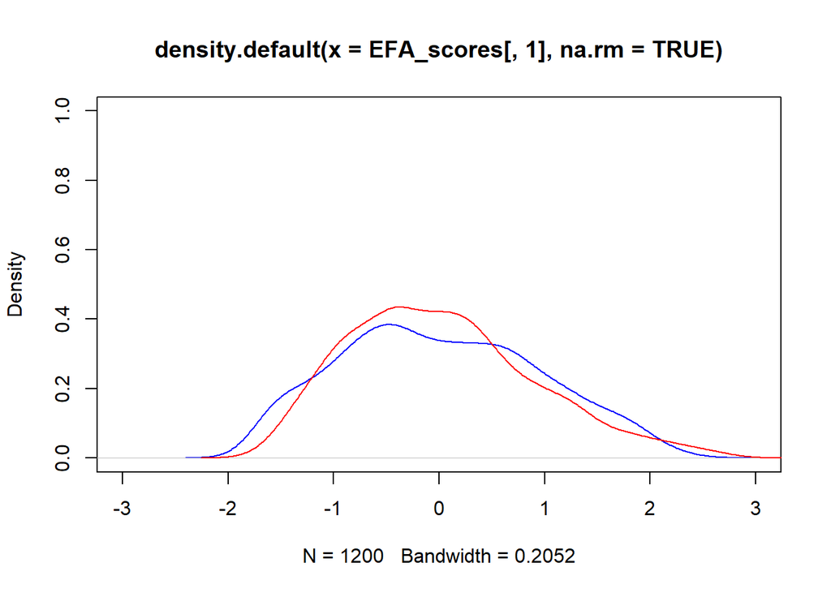

```r
# Extracting factor scores from the EFA model
EFA_scores <- EFA_model$scores

# Calculating factor scores by applying the CFA parameters to the EFA dataset
CFA_scores <- fscores(EFA_CFA, data = bfi_EFA)

# Comparing factor scores from the EFA and CFA results from the bfi_EFA dataset
plot(density(EFA_scores[,1], na.rm = TRUE),
    xlim = c(-3, 3), ylim = c(0, 1), col = "blue")
lines(density(CFA_scores[,1], na.rm = TRUE),
    xlim = c(-3, 3), ylim = c(0, 1), col = "red")
```

As we can see distributions slightly differ. Only slightly.

### Improving the fit

Sometimes it’s beneficial to add new loadings to syntax. For instance EXT and NEU can be loaded by the same items (in fact they are correlated to an extent).

```r
theory_syn_add <- "
AGR: A1, A2, A3, A4, A5
CNS: C1, C2, C3, C4, C5
EXT: E1, E2, E3, E4, E5, N4  # Adding NEU4 to EXT
NEU: N1, N2, N3, N4, N5, E3  # Adding EXT3 to NEU
OPE: O1, O2, O3, O4, O5
"
```

Now, let’s create a new CFA model

```r
# Convert to sem-compatible syntax
theory_syn2 <- cfa(text = theory_syn_add, reference.indicators = FALSE)
```

```
## NOTE: adding 25 variances to the model
```

```r
# Fit the model
theory_CFA_add <- sem(model = theory_syn2, data = bfi_CFA)
summary(theory_CFA_add)
```

```
##
##  Model Chisquare =  2076.95   Df =  263 Pr(>Chisq) = 6.683222e-279
##  Goodness-of-fit index =  0.8679038
##  RMSEA index =  0.0747311   90% CI: (NA, NA)
##  Bentler CFI =  0.7945917
##  BIC =  204.4862
##
##  Normalized Residuals
##    Min. 1st Qu.  Median    Mean 3rd Qu.    Max.
## -5.8787 -0.6580  0.5843  0.8520  2.3094  8.6117
##
##  R-square for Endogenous Variables
##     A1     A2     A3     A4     A5     C1     C2     C3     C4     C5
## 0.1064 0.3825 0.5244 0.2609 0.4713 0.3232 0.3675 0.2548 0.5067 0.3466
##     E1     E2     E3     E4     E5     N4     N1     N2     N3     N5
## 0.3334 0.5286 0.3946 0.5048 0.2923 0.4208 0.6572 0.6028 0.5354 0.2686
##     O1     O2     O3     O4     O5
## 0.3034 0.2224 0.5059 0.0453 0.2109
##
##  Parameter Estimates
##             Estimate    Std Error  z value    Pr(>|z|)
## lam[A1:AGR] -0.45528622 0.04361450 -10.438874  1.647539e-25 A1 <--- AGR
## lam[A2:AGR]  0.72684604 0.03412974  21.296557 1.221790e-100 A2 <--- AGR
## lam[A3:AGR]  0.95306740 0.03706202  25.715476 7.847417e-146 A3 <--- AGR
## lam[A4:AGR]  0.77308579 0.04537380  17.038155  4.280252e-65 A4 <--- AGR
## lam[A5:AGR]  0.88189886 0.03655611  24.124525 1.382380e-128 A5 <--- AGR
## lam[C1:CNS] -0.70342194 0.03728632 -18.865415  2.195422e-79 C1 <--- CNS
## lam[C2:CNS] -0.80592335 0.03968192 -20.309584  1.057973e-91 C2 <--- CNS
## lam[C3:CNS] -0.64735659 0.03927684 -16.481893  4.951012e-61 C3 <--- CNS
## lam[C4:CNS]  0.99515037 0.04073802  24.428052 8.612260e-132 C4 <--- CNS
## lam[C5:CNS]  0.96205814 0.04898991  19.637882  7.339556e-86 C5 <--- CNS
## lam[E1:EXT]  0.94455166 0.04677223  20.194713  1.089586e-90 E1 <--- EXT
## lam[E2:EXT]  1.18682673 0.04408323  26.922408 1.200653e-159 E2 <--- EXT
## lam[E3:EXT] -0.89178616 0.04082707 -21.843011 9.058357e-106 E3 <--- EXT
## lam[E4:EXT] -1.04246376 0.03988888 -26.134198 1.490517e-150 E4 <--- EXT
## lam[E5:EXT] -0.73097373 0.03912966 -18.680812  7.093254e-78 E5 <--- EXT
## lam[N4:EXT]  0.49581226 0.04269450  11.613025  3.538723e-31 N4 <--- EXT
## lam[N1:NEU]  1.27376978 0.04013322  31.738537 4.570492e-221 N1 <--- NEU
## lam[N2:NEU]  1.19154606 0.03977872  29.954358 3.860893e-197 N2 <--- NEU
## lam[N3:NEU]  1.16192109 0.04194797  27.699103 7.158114e-169 N3 <--- NEU
```

[output cut: 30 more lines]

```
## V[E3]        1.15837351 0.05556506  20.847156  1.617560e-96 E3 <--> E3
## V[E4]        1.06596770 0.05560698  19.169674  6.632274e-82 E4 <--> E4
## V[E5]        1.29340127 0.05727905  22.580706 6.706944e-113 E5 <--> E5
## V[N4]        1.47224370 0.06687901  22.013539 2.136459e-107 N4 <--> N4
## V[N1]        0.84612102 0.05388043  15.703678  1.427212e-55 N1 <--> N1
## V[N2]        0.93533643 0.05326880  17.558805  5.093639e-69 N2 <--> N2
## V[N3]        1.17148811 0.06042116  19.388706  9.612436e-84 N3 <--> N3
## V[N5]        1.91471375 0.08264581  23.167705 9.640129e-119 N5 <--> N5
## V[O1]        0.85793085 0.04339511  19.770219  5.374174e-87 O1 <--> O1
## V[O2]        1.86059274 0.08610901  21.607410 1.529938e-103 O2 <--> O2
## V[O3]        0.69575520 0.05224318  13.317628  1.828246e-40 O3 <--> O3
## V[O4]        1.37537821 0.05652432  24.332502 8.881968e-131 O4 <--> O4
## V[O5]        1.38752697 0.06356232  21.829393 1.220297e-105 O5 <--> O5
##
##  Iterations =  34
```

Compare with the previous model

```r
cat(summary(theory_CFA)$BIC, summary(theory_CFA_add)$BIC)
```

```
## 337.6261 204.4862
```

The second model have a much better fit in terms of `BIC`. Let’s see if the differnece statistically significant:

```r
anova(theory_CFA, theory_CFA_add)
```

```
## LR Test for Difference Between Models
##
##                Model Df Model Chisq Df LR Chisq Pr(>Chisq)
## theory_CFA          265      2224.3
## theory_CFA_add      263      2076.9  2   147.38  < 2.2e-16 ***
## ---
## Signif. codes:  0 '***' 0.001 '**' 0.01 '*' 0.05 '.' 0.1 ' ' 1
```

$\chi^2$ for `theory_CFA_add` is lower and the difference is significant at `p < .001`, this result suggests that `theory_CFA_add` has beter fit to the data than `theory_CFA`.

We can also compare CFI values:

```r
cat(summary(theory_CFA)$CFI, summary(theory_CFA_add)$CFI)
```

```
## 0.7781293 0.7945917
```

The higher the CFI value, the better the fit - `theory_CFA_add` is the winner again.

Finally, we can look at `RMSEA`:

```r
cat(summary(theory_CFA)$RMSEA[1], summary(theory_CFA_add)$RMSEA[1])
```

```
## 0.07737441 0.0747311
```

Again, `theory_CFA_add` wins.